# Data 608 Assignment 1 - Jithendra (Jit) Seneviratne

**Principles of Data Visualization and Introduction to ggplot2**

I have provided you with data about the 5,000 fastest growing companies in the US, as compiled by Inc. magazine. lets read this in:

```r
library(dplyr)
```

```r
library(ggplot2)
inc <- read.csv("https://raw.githubusercontent.com/charleyferrari/CUNY_DATA_608/master/module1/Data/inc5000_data.csv", header= TRUE)
```

And lets preview this data:

```r
head(inc)
```

```
##   Rank                         Name Growth_Rate   Revenue
## 1    1                         Fuhu      421.48 1.179e+08
## 2    2        FederalConference.com      248.31 4.960e+07
## 3    3                The HCI Group      245.45 2.550e+07
## 4    4                      Bridger      233.08 1.900e+09
## 5    5                       DataXu      213.37 8.700e+07
## 6    6 MileStone Community Builders      179.38 4.570e+07
##                       Industry Employees         City State
## 1 Consumer Products & Services       104   El Segundo    CA
## 2          Government Services        51     Dumfries    VA
## 3                       Health       132 Jacksonville    FL
## 4                       Energy        50      Addison    TX
## 5      Advertising & Marketing       220       Boston    MA
## 6                  Real Estate        63       Austin    TX
```

```r
summary(inc)
```

```
##       Rank                          Name       Growth_Rate
##  Min.   :   1   (Add)ventures         :   1   Min.   :  0.340
##  1st Qu.:1252   @Properties           :   1   1st Qu.:  0.770
##  Median :2502   1-Stop Translation USA:   1   Median :  1.420
##  Mean   :2502   110 Consulting        :   1   Mean   :  4.612
##  3rd Qu.:3751   11thStreetCoffee.com  :   1   3rd Qu.:  3.290
##  Max.   :5000   123 Exteriors         :   1   Max.   :421.480
##                 (Other)               :4995
##     Revenue                                  Industry      Employees
##  Min.   :2.000e+06   IT Services                 : 733   Min.   :    1.0
##  1st Qu.:5.100e+06   Business Products & Services: 482   1st Qu.:   25.0
##  Median :1.090e+07   Advertising & Marketing     : 471   Median :   53.0
##  Mean   :4.822e+07   Health                      : 355   Mean   :  232.7
##  3rd Qu.:2.860e+07   Software                    : 342   3rd Qu.:  132.0
##  Max.   :1.010e+10   Financial Services          : 260   Max.   :66803.0
##                      (Other)                     :2358   NA's   :12
##             City          State
##  New York     : 160   CA     : 701
##  Chicago      :  90   TX     : 387
##  Austin       :  88   NY     : 311
##  Houston      :  76   VA     : 283
##  San Francisco:  75   FL     : 282
##  Atlanta      :  74   IL     : 273
##  (Other)      :4438   (Other):2764
```

Think a bit on what these summaries mean. Use the space below to add some more relevant non-visual exploratory information you think helps you understand this data:

## Further EDA

##### Let’s check the correlation between some of the numerical variables. Let’s see if company size (in terms of head count) has a relationship with growth rates.

```r
# Insert your code here, create more chunks as necessary
cor(na.omit(inc)[c(3:4,6)], method = c("pearson", "kendall", "spearman"))
```

```
##              Growth_Rate     Revenue  Employees
## Growth_Rate  1.000000000 0.006328055 -0.0178689
## Revenue      0.006328055 1.000000000  0.2779332
## Employees   -0.017868897 0.277933213  1.0000000
```

##### We don’t see a tremendous amount of correlation, apart from employee size and revenue, which is to be expected. Let’s also check how many null values each feature in our dataset has.

```r
inc %>%
  summarise_all(funs(sum(is.na(.))))
```

```
##   Rank Name Growth_Rate Revenue Industry Employees City State
## 1    0    0           0       0        0        12    0     0
```

##### We have twelve incomplete items, where the employee count information is missing. Let’s also look at which companies have the highest revenue, along with the companies with the highest growth rates.

```r
inc %>%
     arrange(desc(Revenue)) %>%
  head()
```

```
##   Rank                       Name Growth_Rate  Revenue
## 1 4788                        CDW        0.41 1.01e+10
## 2 3853                 ABC Supply        0.73 4.70e+09
## 3 4936                       Coty        0.36 4.60e+09
## 4 4997                  Dot Foods        0.34 4.50e+09
## 5 4716              Westcon Group        0.44 3.80e+09
## 6 4246 American Tire Distributors        0.59 3.50e+09
##                       Industry Employees         City State
## 1            Computer Hardware      6800 Vernon Hills    IL
## 2                 Construction      6549       Beloit    WI
## 3 Consumer Products & Services     10000     New York    NY
## 4              Food & Beverage      3919 Mt. Sterling    IL
## 5                  IT Services      3000    Tarrytown    NY
## 6 Consumer Products & Services      3341 Huntersville    NC
```

```r
inc %>%
  arrange(desc(Growth_Rate)) %>%
  head()
```

```
##   Rank                         Name Growth_Rate   Revenue
## 1    1                         Fuhu      421.48 1.179e+08
## 2    2        FederalConference.com      248.31 4.960e+07
## 3    3                The HCI Group      245.45 2.550e+07
## 4    4                      Bridger      233.08 1.900e+09
## 5    5                       DataXu      213.37 8.700e+07
## 6    6 MileStone Community Builders      179.38 4.570e+07
##                       Industry Employees         City State
## 1 Consumer Products & Services       104   El Segundo    CA
## 2          Government Services        51     Dumfries    VA
## 3                       Health       132 Jacksonville    FL
## 4                       Energy        50      Addison    TX
## 5      Advertising & Marketing       220       Boston    MA
## 6                  Real Estate        63       Austin    TX
```

##### We can see that the companies with highest growth rates are not related to the ones with highest revenue. Our correlation matrix proved this.

## Question 1

Create a graph that shows the distribution of companies in the dataset by State (ie how many are in each state). There are a lot of States, so consider which axis you should use. This visualization is ultimately going to be consumed on a ‘portrait’ oriented screen (ie taller than wide), which should further guide your layout choices.

#### We’ll first grab states with the highest volume of companies, and group the rest into a column called ‘Other’.

```r
# Answer Question 1 here
inc_state_summary <- inc %>%
                      group_by(State) %>%
                      summarise(
                        number = n_distinct(Name),
                      ) %>%
                      arrange(desc(number))

inc_state_summary <- rbind(inc_state_summary[c(1:24),],
                           (inc_state_summary[c(25:nrow(inc_state_summary)),] %>%
                            summarise(
                            State = 'Other',
                            number = sum(number))))
inc_state_summary
```

```
## # A tibble: 25 x 2
##    State number
##    <fct>  <int>
##  1 CA       701
##  2 TX       387
##  3 NY       311
##  4 VA       283
##  5 FL       282
##  6 IL       273
##  7 GA       212
##  8 OH       186
##  9 MA       182
## 10 PA       164
## # … with 15 more rows
```

### Horizontal Bar Chart

##### Let’s plot the results. Note that we are making some adjustments to ensure the order is preserved. Also, we want to show ‘Other’ at the end, even if it has a high count. Let’s also get rid of the legend, since it’ll add no value here.

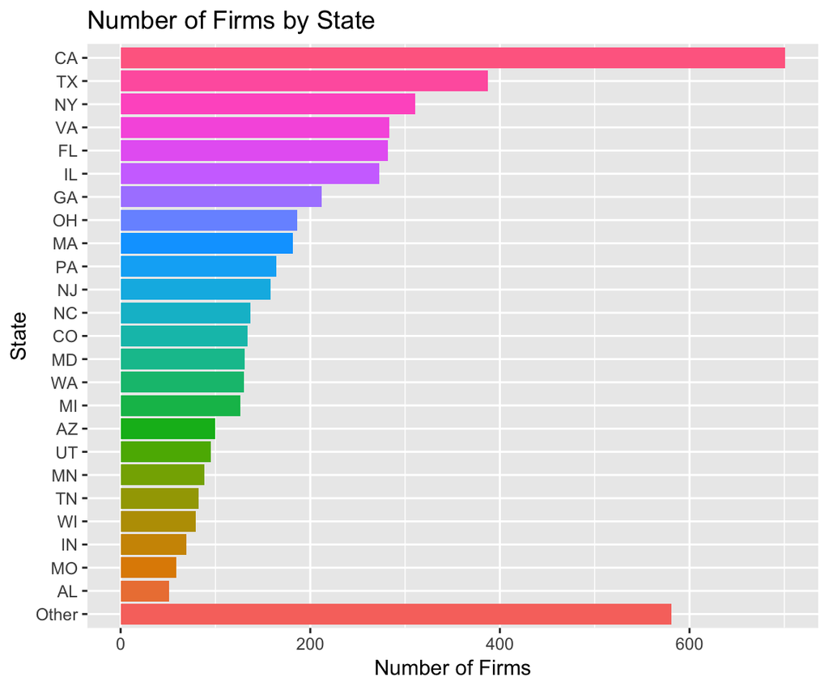

```r
inc_state_summary$State <- factor(inc_state_summary$State, levels = rev(inc_state_summary$State))

ggplot(inc_state_summary ,
       aes(State,
           number)) +
  geom_bar(stat="identity",
            aes(fill=State)) +
  coord_flip() +
  ggtitle("Number of Firms by State") +
  ylab("Number of Firms") +
  xlab("State") +
  theme(legend.position = "none")
```

## Quesiton 2

Lets dig in on the state with the 3rd most companies in the data set. Imagine you work for the state and are interested in how many people are employed by companies in different industries. Create a plot that shows the average and/or median employment by industry for companies in this state (only use cases with full data, use R’s `complete.cases()` function.) In addition to this, your graph should show how variable the ranges are, and you should deal with outliers.

##### We’ll filter for New York State (the state with the 3rd most companies in the dataset). Let’s once again grab the industries with the highest employee count, and group the rest into an ‘Other’ column. We’ll grab the median and standard deviation for employees in companies by industry. Note that we’ll have to filter out industries with fewer than two companies, since we can’t get aggregate metrics for those.

```r
# Answer Question 2 here

# pre group dataframe
inc_pre_group <- inc[complete.cases(inc),] %>%
                      filter(State=='NY')

top_industries <- (inc_pre_group %>%
                      group_by(Industry) %>%
                      summarise(
                        total_emp = sum(Employees),
                      ) %>%
                      arrange(desc(total_emp)))$Industry[1:10]

inc_pre_group$Industry <- as.character(inc_pre_group$Industry)

inc_pre_group$Industry[!inc_pre_group$Industry %in% top_industries] <- 'Other'

# grouped dataframe
inc_ny <- inc_pre_group %>%
            group_by(Industry) %>%
            summarise(
              number = n_distinct(Name),
              Med_emp = median(Employees, na.rm = TRUE),
              Std_emp = var(Employees, na.rm = TRUE)^(.5)
            ) %>%
            filter(number > 1) %>%
            arrange(desc(Med_emp))

# Make sure 'Other' factor is shown last
inc_ny <- rbind(inc_ny[!inc_ny$Industry == 'Other',],
                inc_ny[inc_ny$Industry == 'Other',])
inc_ny
```

```
## # A tibble: 11 x 4
##    Industry                     number Med_emp Std_emp
##    <chr>                         <int>   <dbl>   <dbl>
##  1 Financial Services               13    81     152.
##  2 Software                         13    80     375.
##  3 Business Products & Services     26    70.5  6241.
##  4 Travel & Hospitality              7    61     835.
##  5 Human Resources                  11    56     681.
##  6 IT Services                      43    54     473.
##  7 Media                            11    45     176.
##  8 Advertising & Marketing          57    38      62.2
##  9 Telecommunications               17    31     103.
## 10 Consumer Products & Services     17    25    2416.
## 11 Other                            96    30.5    84.4
```

### Bubble Plot

##### Let’s first plot the results in a bubble plot.

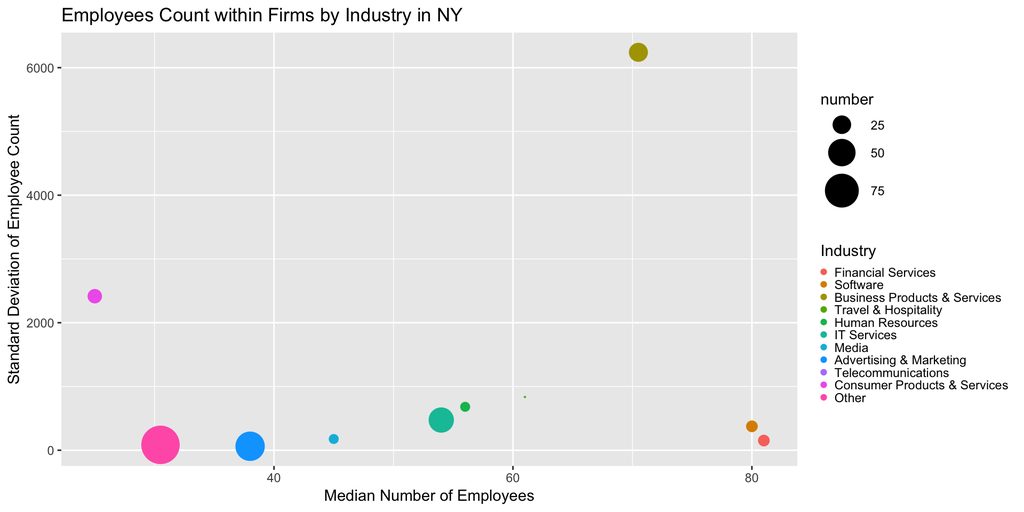

```r
# Preserve order of factors
inc_ny$Industry <- factor(inc_ny$Industry, levels = inc_ny$Industry)

bubble_ny <- ggplot(inc_ny, aes(Med_emp,
                        Std_emp,
                        size = number,
                        color = Industry))
bubble_ny +
geom_point() +
theme(legend.key=element_blank(), legend.key.size=unit(.3,"point")) +
guides(colour=guide_legend(nrow=20)) +
ggtitle("Employees Count within Firms by Industry in NY") +
ylab("Standard Deviation of Employee Count") +
xlab("Median Number of Employees") +
scale_size(range = c(.1, 12))
```

### Box and Whisker Plot

##### We can see that Business Products and Services clearly has a lot of variance in its portfolio of companies. Next, let’s visualize the distribution of head-count by industry using a box and whisker plot.

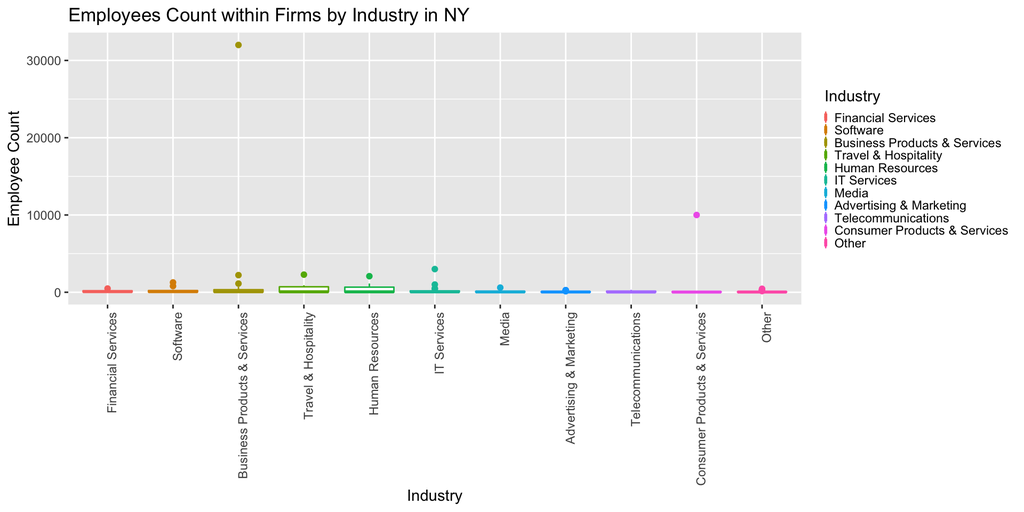

```r
# Preserve order of factors
inc_pre_group$Industry <- factor(inc_pre_group$Industry, levels = inc_ny$Industry)

inc_box_plot <- ggplot(inc_pre_group,
                       aes(Industry,
                           Employees,
                           color = Industry))
inc_box_plot +
geom_boxplot() +
theme(axis.text.x = element_text(angle = 90, hjust = 1),
     legend.key=element_blank(),
     legend.key.size=unit(.4,"point")) +
ggtitle("Employees Count within Firms by Industry in NY") +
ylab("Employee Count") +
xlab("Industry")
```

### Dealing with Outliers

##### We can see that the outliers are not allowing us to analyze the important information closely. Fortunately, since the plots show the median and quartiles, the plots are robust to outliers. Let’s zoom in and try again.

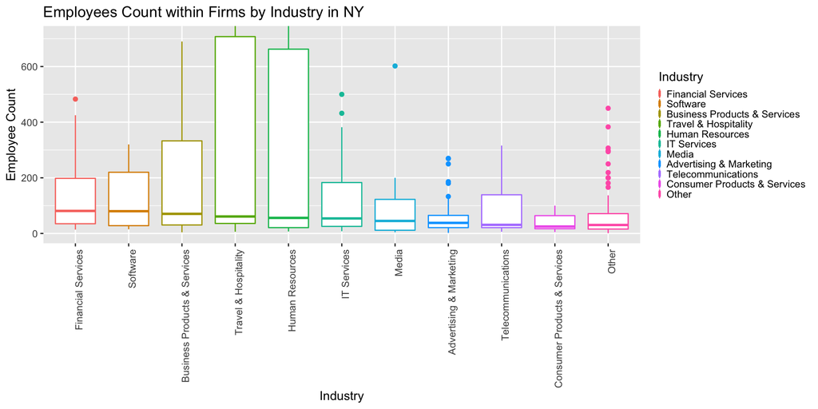

```r
inc_box_plot +
geom_boxplot() +
theme(axis.text.x = element_text(angle = 90, hjust = 1),
     legend.key=element_blank(),
     legend.key.size=unit(.4,"point")) +
ggtitle("Employees Count within Firms by Industry in NY") +
ylab("Employee Count") +
xlab("Industry") +
coord_cartesian(ylim = c(0, 710))
```

## Question 3

Now imagine you work for an investor and want to see which industries generate the most revenue per employee. Create a chart that makes this information clear. Once again, the distribution per industry should be shown.

##### Since we want to preserve the distributions, we cannot group our data. However, we can create a temporary grouping to get industries with the highest median revenue per employee. We’ll lump the rest into a category called ‘Other’ again.

```r
# Only complete cases
inc_rev <- inc[complete.cases(inc),]

# Temporary grouping to get top industries
top_industries <- (inc_rev %>%
            group_by(Industry) %>%
            summarise(Med_rev_emp = median(Revenue/Employees)) %>%
                      arrange(desc(Med_rev_emp)) %>%
                      select(Industry))$Industry[1:10]

inc_rev$Industry <- as.character(inc_rev$Industry)

inc_rev$Industry[!inc_rev$Industry %in% top_industries] <- 'Other'

# Create column for revenue per employee
inc_rev <- inc_rev %>%
            mutate(Rev_emp = Revenue/Employees)
```

### Box and Whisker Plot

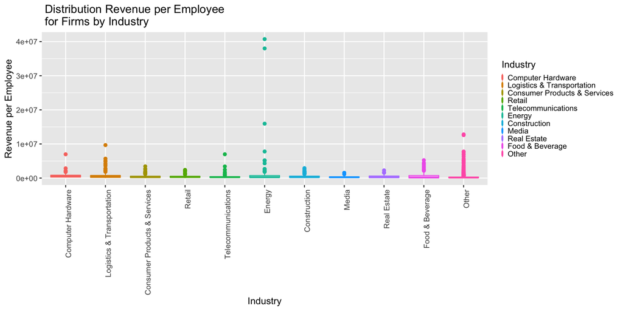

```r
inc_rev$Industry <- factor(inc_rev$Industry, levels = c(as.character(top_industries),'Other'))

rev_box_plot <- ggplot(inc_rev,
                       aes(Industry,
                           Rev_emp,
                           color = Industry))
rev_box_plot +
geom_boxplot() +
theme(axis.text.x = element_text(angle = 90, hjust = 1),
     legend.key=element_blank(),
     legend.key.size=unit(.4,"point")) +
ggtitle(" Distribution Revenue per Employee \n for Firms by Industry") +
ylab("Revenue per Employee") +
xlab("Industry")
```

### Dealing with Outliers

##### We can see that the ‘Energy’ subset has extreme outliers that make comparisons hard. Let’s zoom in

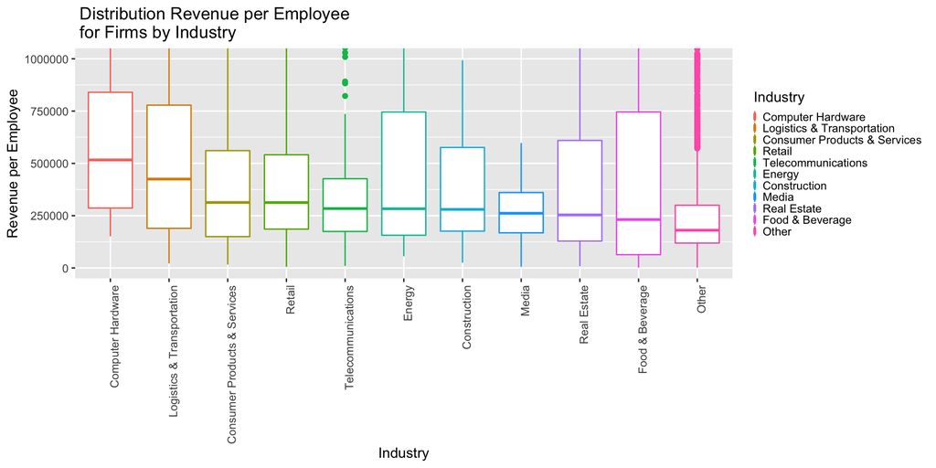

```r
rev_box_plot +
geom_boxplot() +
theme(axis.text.x = element_text(angle = 90, hjust = 1),
     legend.key=element_blank(),
     legend.key.size=unit(.4,"point")) +
ggtitle(" Distribution Revenue per Employee \n for Firms by Industry") +
ylab("Revenue per Employee") +
xlab("Industry") +
coord_cartesian(ylim = c(0, 1000000))
```

### Bubble Chart

##### Let’s get back to bubble charts and visualize indistry, median revenue per employee, median employee count as well as median revenue. We’ll first need to create our dataframe.

```r
# grouped dataframe
inc_rev_group <- inc_rev %>%
                  group_by(Industry) %>%
                  summarise(
                    Number = n_distinct(Name),
                    Med_emp = median(Employees, na.rm = TRUE),
                    Med_rev_emp = median(Rev_emp),
                    Med_rev = median(Revenue)
                  ) %>%
                  filter(Number > 1) %>%
                  arrange(desc(Med_emp))

# Make sure 'Other' factor is shown last
inc_rev_group <- rbind(inc_rev_group[!inc_rev_group$Industry == 'Other',],
                       inc_rev_group[inc_rev_group$Industry == 'Other',])
inc_rev_group
```

```
## # A tibble: 11 x 5
##    Industry                     Number Med_emp Med_rev_emp  Med_rev
##    <fct>                         <int>   <dbl>       <dbl>    <dbl>
##  1 Energy                          109    70       283212. 29400000
##  2 Telecommunications              127    65       284000  16600000
##  3 Food & Beverage                 129    65       231373. 18600000
##  4 Logistics & Transportation      154    50       425024. 20800000
##  5 Real Estate                      95    49       253571. 13300000
##  6 Construction                    187    47       280000  14000000
##  7 Computer Hardware                44    45.5     516477. 22350000
##  8 Consumer Products & Services    203    34       313043.  9400000
##  9 Media                            54    34       261458.  7600000
## 10 Retail                          203    31       312755.  8200000
## 11 Other                          3684    55       180546. 10100000
```

##### Plot the results

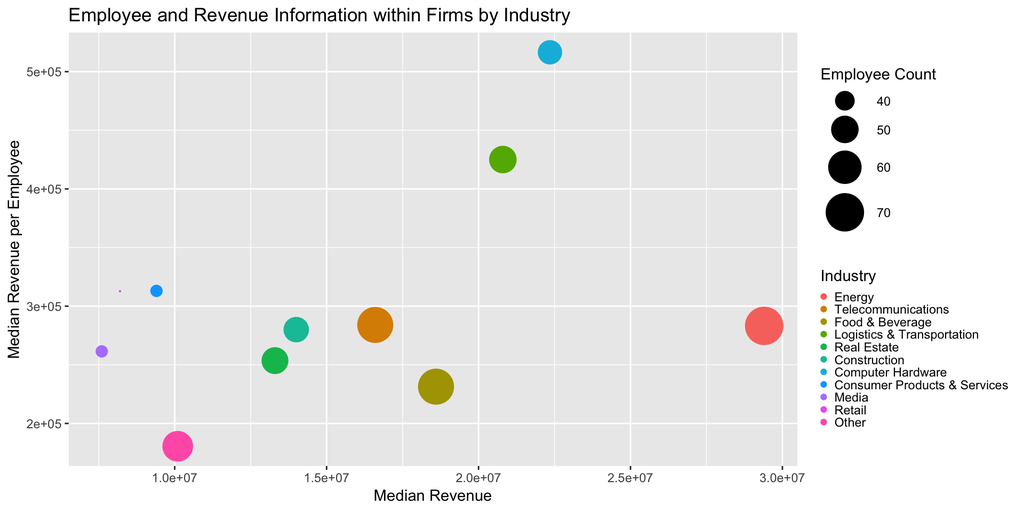

```r
# Preserve order of factors
inc_rev_group$Industry <- factor(inc_rev_group$Industry, levels = inc_rev_group$Industry)
bubble_rev <- ggplot(inc_rev_group, aes(Med_rev,
                                        Med_rev_emp,
                                        size = Med_emp,
                                        color = Industry))
bubble_rev +
geom_point() +
theme(legend.key=element_blank(), legend.key.size=unit(.3,"point")) +
guides(colour=guide_legend(nrow=20)) +
ggtitle("Employee and Revenue Information within Firms by Industry") +
ylab("Median Revenue per Employee") +
xlab("Median Revenue") +
scale_size(range = c(.1, 12)) +
labs(size = "Employee Count")
```